# Plant Chemotypes

Mixutre Based Clustering Algorithm

Navankur Verma - navankurverma@gmail.com

18/03/2020

### (a) Classical Metric Scaling

```r
library(nomclust)
hyptis <- read.csv("Hyptis.csv")
str(hyptis)
```

```
## 'data.frame':    30 obs. of  8 variables:
##  $ Sabinene   : num  6.22 14.46 5.13 3.09 23.98 ...
##  $ Pinene     : num  4.11 5.93 3.82 0.74 4.38 3.17 3.52 4.42 3.46 4.29 ...
##  $ Cineole    : num  22.31 28.17 21.87 0.78 11.49 ...
##  $ Terpinene  : num  5.42 2.34 8.33 13.05 2.69 ...
##  $ Fenchone   : num  4.72 4.74 4.48 1.2 12.36 ...
##  $ Terpinolene: num  0 0 0 0 0 0 0 0 0 0 ...
##  $ Fenchol    : num  16.12 5.34 16.18 22.47 11.02 ...
##  $ Location   : Factor w/ 4 levels "East-high","East-low",..: 4 4 4 4 4 4 4 4 4 4 ...
```

```r
locations <- hyptis$Location #extracting the known locations
#creating matrix from the observed variables, to be used as argument of dist command
dat <- as.matrix(hyptis[,c(1:7)])

#changing the labels of levels, to make visualization neat
levels(locations) <- c("E-H","E-L","N","S")

out <- matrix(NA, nrow = 3, ncol = 3) #matrix to store measurements of models

for (x in 2:4) {
  loc <- cmdscale(dist(dat),k =x, eig = TRUE)
  out[x-1,] <- c(x,sum(abs(loc$eig[1:x]))/sum(abs(loc$eig)),loc$GOF[1])
}
colnames(out) <- c("Dimensions", "Proportion of Variance","Goodness of Fit")
knitr::kable(out)
```

| Dimensions | Proportion of Variance | Goodness of Fit |
| --- | --- | --- |
| 2 | 0.7340443 | 0.7340443 |
| 3 | 0.8592943 | 0.8592943 |
| 4 | 0.9657085 | 0.9657085 |

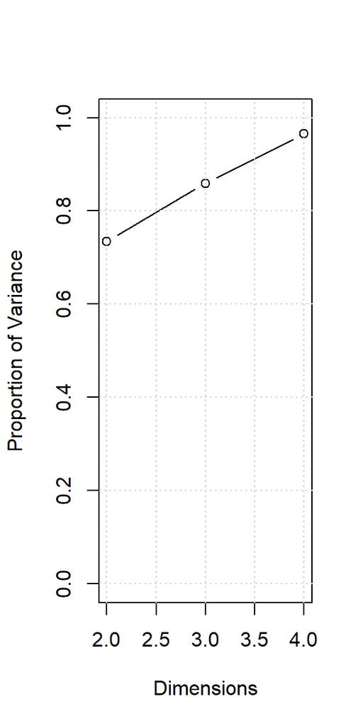

```r
plot(out[,1], out[,2], ylim = c(0,1), type = "b", xlab = "Dimensions", ylab = "Proportion of Variance")
grid()
```

With 2 dimensions, proportion of variance is 73 which is not that good we loose a quarter of information on the dissimilarity in our data. With 3 dimensions, it is almost 86% which gives a good fit with our original data.

Visualizing the datapoints in the new coordinates:

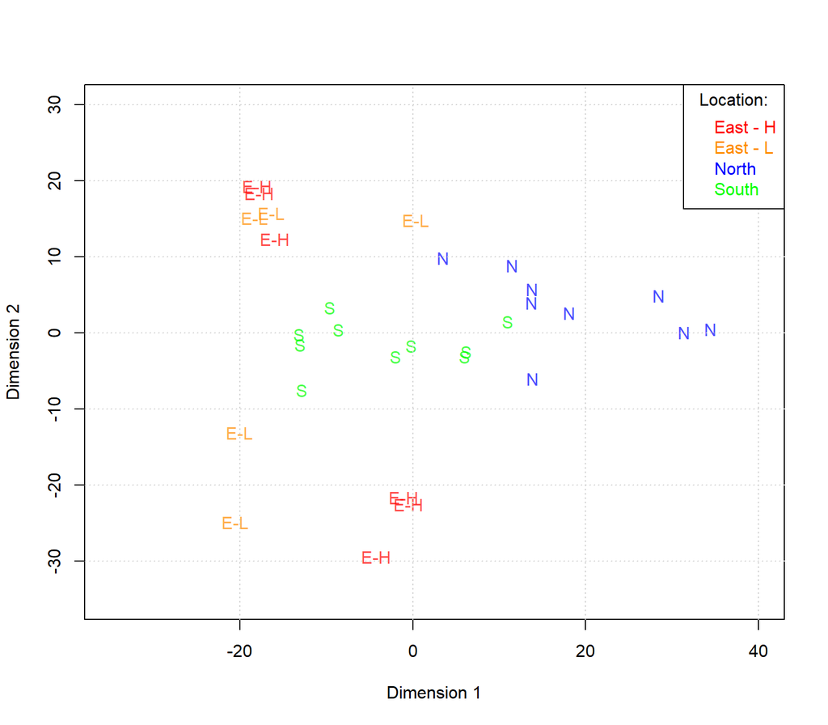

```r
colvec <- c("red","darkorange","blue","green")
fit12 <- cmdscale(dist(dat),k =2, eig = TRUE)
x1 <- fit12$points[,1]
y1 <- fit12$points[,2]
plot(x1,y1, ylim = c(-35,30), xlim = c(-35,40),  xlab = "Dimension 1", ylab = "Dimension 2", type = "n")
text(x1,y1, locations , col= adjustcolor(colvec[locations], 0.7), pch = 19)
grid()
legend("topright",legend =  c("East - H","East - L","North", "South"), title ="Location:", title.col = "Black" , text.col = colvec)
```

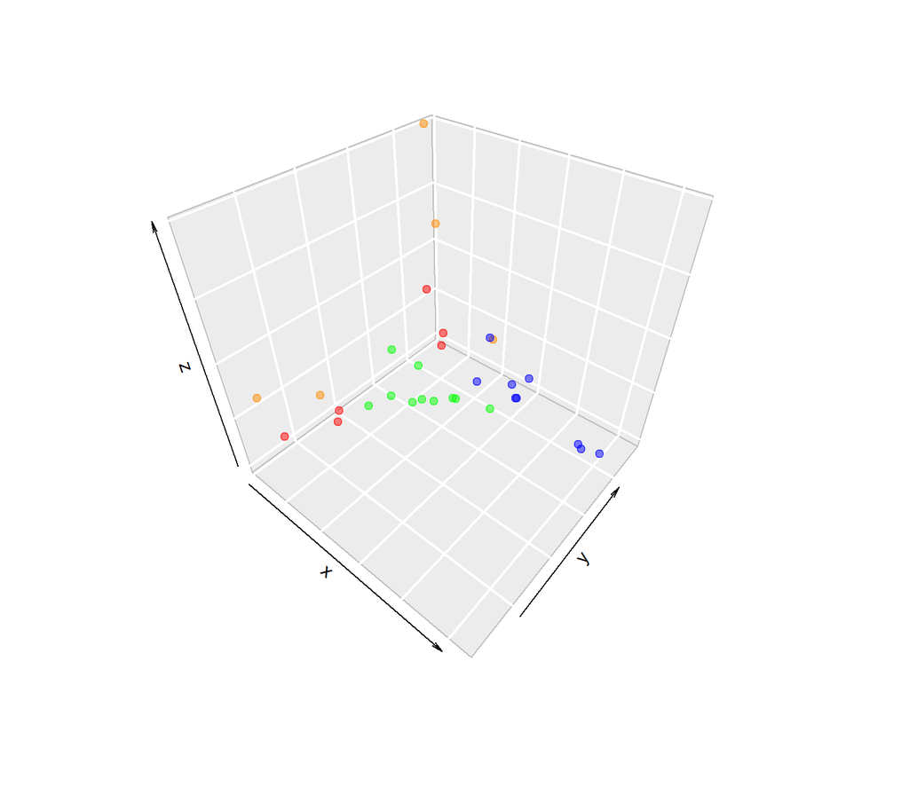

```r
fit13 <- cmdscale(dist(dat),k =3, eig = TRUE)
library(plot3D)
scatter3D(loc$points[,1],loc$points[,2],loc$points[,3],
          colvar = NULL, col = adjustcolor(colvec[locations], 0.5),
          pch = 19, bty = "g", phi = 40)
```

### (b) Sammon and Kruskal Scaling

```r
library(MASS)
fit22 <- sammon(dist(dat),k =2, niter = 1000, tol = 1e-6)
```

```
## Initial stress        : 0.06787
## stress after  10 iters: 0.02647, magic = 0.500
## stress after  20 iters: 0.02612, magic = 0.500
## stress after  30 iters: 0.02546, magic = 0.500
## stress after  40 iters: 0.02464, magic = 0.500
## stress after  50 iters: 0.02446, magic = 0.500
## stress after  60 iters: 0.02445, magic = 0.500
## stress after  70 iters: 0.02445, magic = 0.500
```

```r
x2 <- fit22$points[,1]
y2 <- fit22$points[,2]

fit32 <- isoMDS(dist(dat),k =2 , maxit = 1000, tol = 1e-6)
```

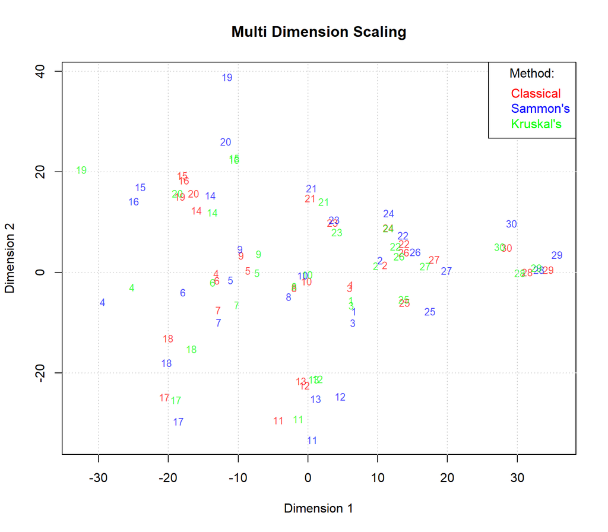

```r
x3 <- fit32$points[,1]
y3 <- fit32$points[,2]

plot(x2,y2,type = "n",
     xlim = c(min(x1,x2,x3),max(x1,x2,x3)),
     ylim = c(min(y1,y2,y3),max(y1,y2,y3)),
     xlab = "Dimension 1", ylab = "Dimension 2",
     main = "Multi Dimension Scaling")
text(x1,y1,rownames(hyptis),cex=.8,col=adjustcolor("red", alpha.f = 0.7))
text(x2,y2,rownames(hyptis),cex=.8,col=adjustcolor("blue", alpha.f = 0.7))
text(x3,y3,rownames(hyptis),cex=.8,col=adjustcolor("green", alpha.f = 0.7))
grid()
legend("topright",legend =  c("Classical","Sammon's","Kruskal's"), title ="Method:", title.col = "Black" , text.col = c("red","blue","green"))
```

### (c) Procrustes Analysis:

```r
library(vegan)
proc12 = procrustes(fit12$points, fit22$points)
proc23 = procrustes(fit22$points, fit32$points)
proc31 = procrustes(fit32$points, fit12$points)

sumsq <- c(proc12$ss,proc23$ss,proc31$ss)
sumsq <- as.data.frame(sumsq)
row.names(sumsq) <- c("Classical Vs Sammon","Sammon Vs Kruskal", "Classical Vs Kruskal")
kable(sumsq)
```

|  | sumsq |
| --- | --- |
| Classical Vs Sammon | 945.9168 |
| Sammon Vs Kruskal | 1663.5538 |
| Classical Vs Kruskal | 625.2623 |

Classical and Kruskal’s configurations matches the best of all other combinations as the Procrustes sum of squares is least between these two configurations. And also the plot of residuals shows that residuals between the Classical and Kruskals configuration are least of all:

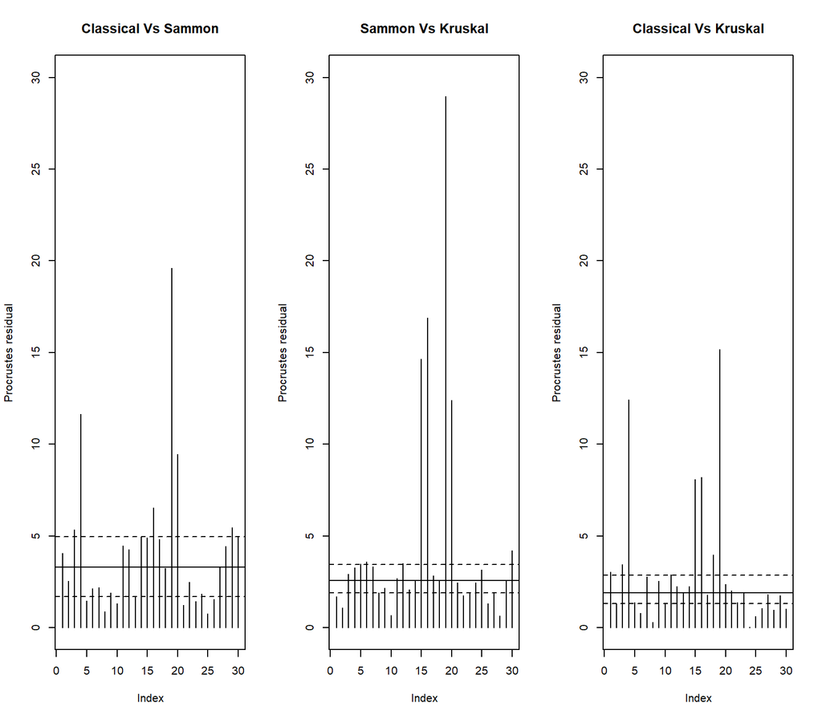

```r
par(mfrow =c(1,3))
plot(proc12, kind = 2, ylim = c(0,30), main = "Classical Vs Sammon")
plot(proc23, kind = 2, ylim = c(0,30), main = "Sammon Vs Kruskal")
plot(proc31, kind = 2, ylim = c(0,30), main = "Classical Vs Kruskal")
```

```r
par(mfrow =c(1,1))
```

### (d) Model Based Clustering

```r
library(mclust)
res <- Mclust(dat, G = 1:9)
summary(res)
```

```
## ----------------------------------------------------
## Gaussian finite mixture model fitted by EM algorithm
## ----------------------------------------------------
##
## Mclust VEV (ellipsoidal, equal shape) model with 6 components:
##
##  log-likelihood  n  df       BIC       ICL
##        -273.297 30 185 -1175.816 -1175.816
##
## Clustering table:
##  1  2  3  4  5  6
## 10  8  4  3  2  3
```

```r
summary(res$BIC)
```

```
## Best BIC values:
##              VEV,6       EEV,5      EEV,4
## BIC      -1175.816 -1273.18749 -1286.3796
## BIC diff     0.000   -97.37192  -110.5641
```

MClust suggests VEV model with 6 cluster as optimal, with its BIC -1175.8155739, highest among all other competing models. 1st character “V”, explains that each cluster has its own size, 2nd character “E” explains that each cluster have equal shape and 3rd character “V” explains that each cluster has varying orientations.

It also suggest that next best models are of type EEV, with their BICs almost 100 units less than VEV. Although the parameters required to be estimated in VEV are more than in EEV types model with lower classes, but still it gives a parsimonous model which fits well with the data with likelihood of -273.2970292.

```r
#Size of each predicted cluster:
table(res$classification)
```

```
##
##  1  2  3  4  5  6
## 10  8  4  3  2  3
```

```r
prop.table(table(res$classification))
```

```
##
##          1          2          3          4          5          6
## 0.33333333 0.26666667 0.13333333 0.10000000 0.06666667 0.10000000
```

```r
#From this only,the mixing proportions of each class is calculated:
res$parameters$pro
```

```
## [1] 0.33333334 0.26666666 0.13333333 0.10000000 0.06666667 0.10000000
```

Visualizing how all the models performed:

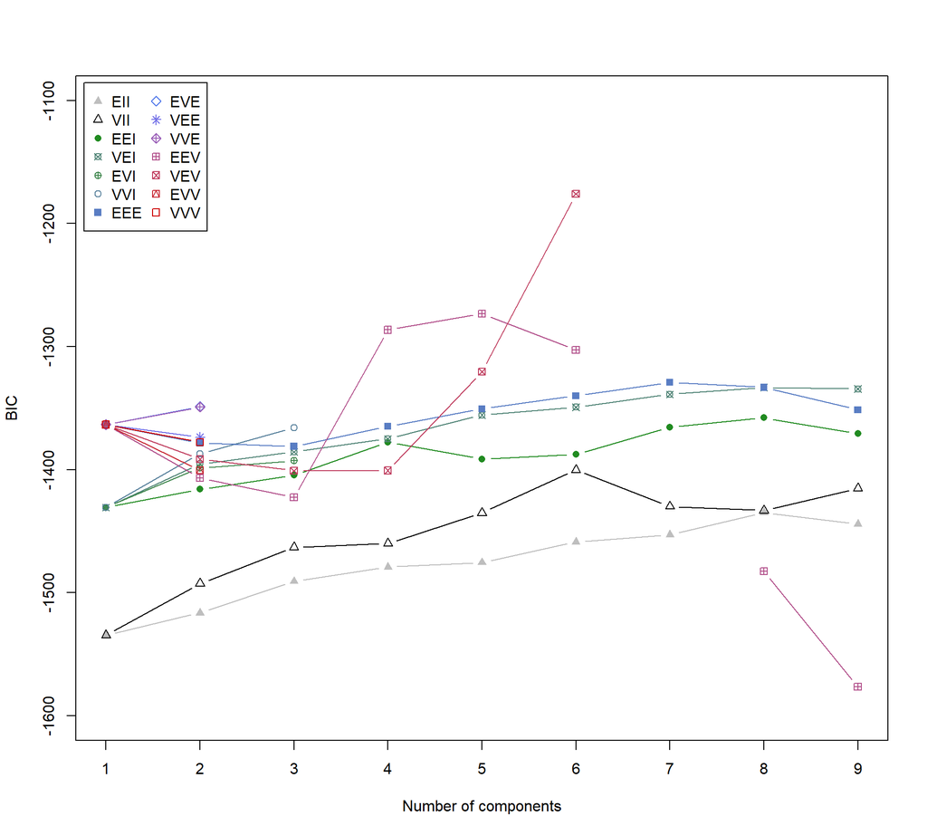

```r
plot(res, what = "BIC", legendArgs = list(x="topleft", cex = 1), ylim = c(-1600,-1100))
```

Visualizing the data points with their predicted clusters:

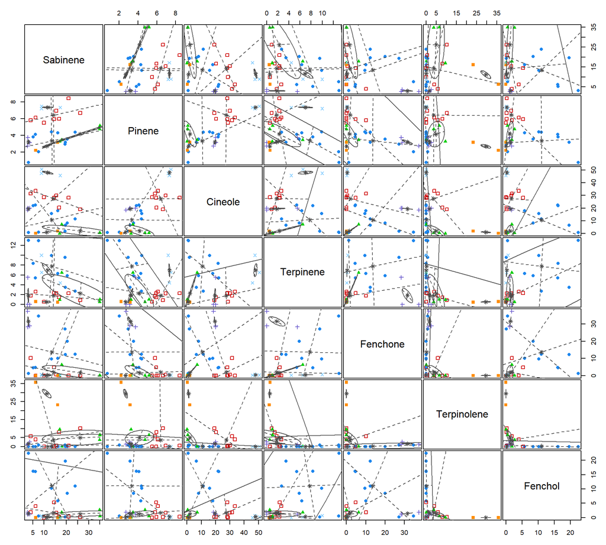

```r
plot(res, what = "classification")
```

Uncertainity of data points in their corresponding class assignment:

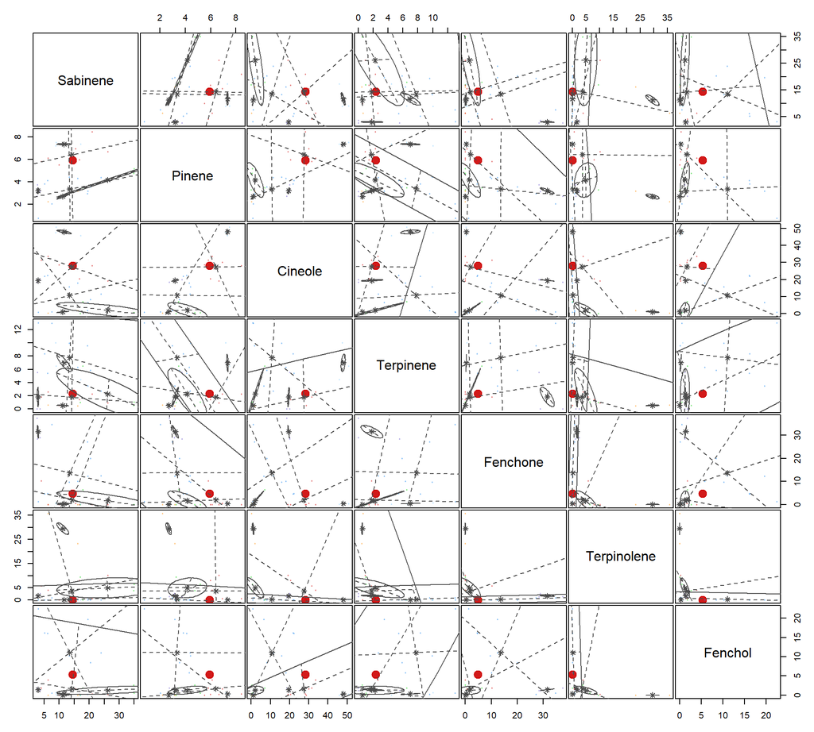

```r
plot(res, what = "uncertain")
```

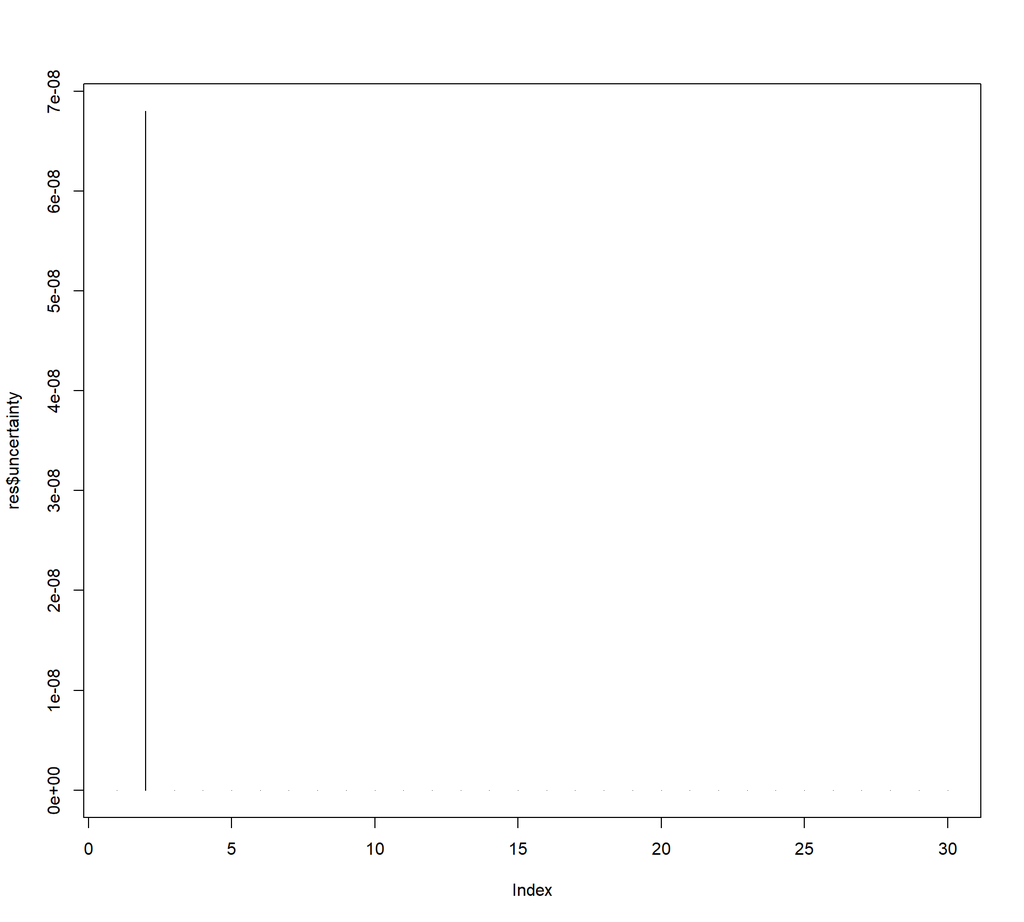

```r
plot(res$uncertainty, type = "h")
```

```r
#Mean of variables corresponding to each cluster:
kable(res$parameters$mean)
```

| Sabinene | 13.493 | 14.26375 | 26.1750 | 2.993333 | 11.215 | 11.6600000 |
| --- | --- | --- | --- | --- | --- | --- |
| Pinene | 3.341 | 6.41875 | 4.1550 | 3.193333 | 2.680 | 7.3400000 |
| Cineole | 10.784 | 27.44500 | 2.0325 | 19.483333 | 1.050 | 47.9533333 |
| Terpinene | 7.765 | 1.77500 | 2.2600 | 1.836667 | 0.535 | 6.9833333 |
| Fenchone | 13.644 | 1.92875 | 1.5725 | 31.553333 | 0.000 | 0.3666667 |
| Terpinolene | 0.160 | 3.62750 | 4.9100 | 1.646667 | 29.510 | 0.0000000 |
| Fenchol | 11.081 | 1.69750 | 1.2550 | 1.420000 | 0.000 | 0.2900000 |

```r
#predicted cluster of 2nd observation:
res$classification[2]
```

```
## [1] 2
```

```r
#Actual values of 2nd observation:
kable(hyptis[2,])
```

|  | Sabinene | Pinene | Cineole | Terpinene | Fenchone | Terpinolene | Fenchol | Location |
| --- | --- | --- | --- | --- | --- | --- | --- | --- |
| 2 | 14.46 | 5.93 | 28.17 | 2.34 | 4.74 | 0 | 5.34 | South |

```r
table(locations, res$classification)
```

```
##
## locations 1 2 3 4 5 6
##       E-H 0 0 3 3 0 0
##       E-L 2 1 0 0 2 0
##       N   0 6 0 0 0 3
##       S   8 1 1 0 0 0
```

```r
adjustedRandIndex(locations, res$classification)
```

```
## [1] 0.4403259
```

There is not much agreement between the locations where plants were grown and the clusters predicted using mode based cluster.